# InVivoStat Single Measure Parametric Analysis

## Response

The Resp 13 response is currently being analysed by the Single Measures Parametric Analysis module.

## Scatterplot of the observed data

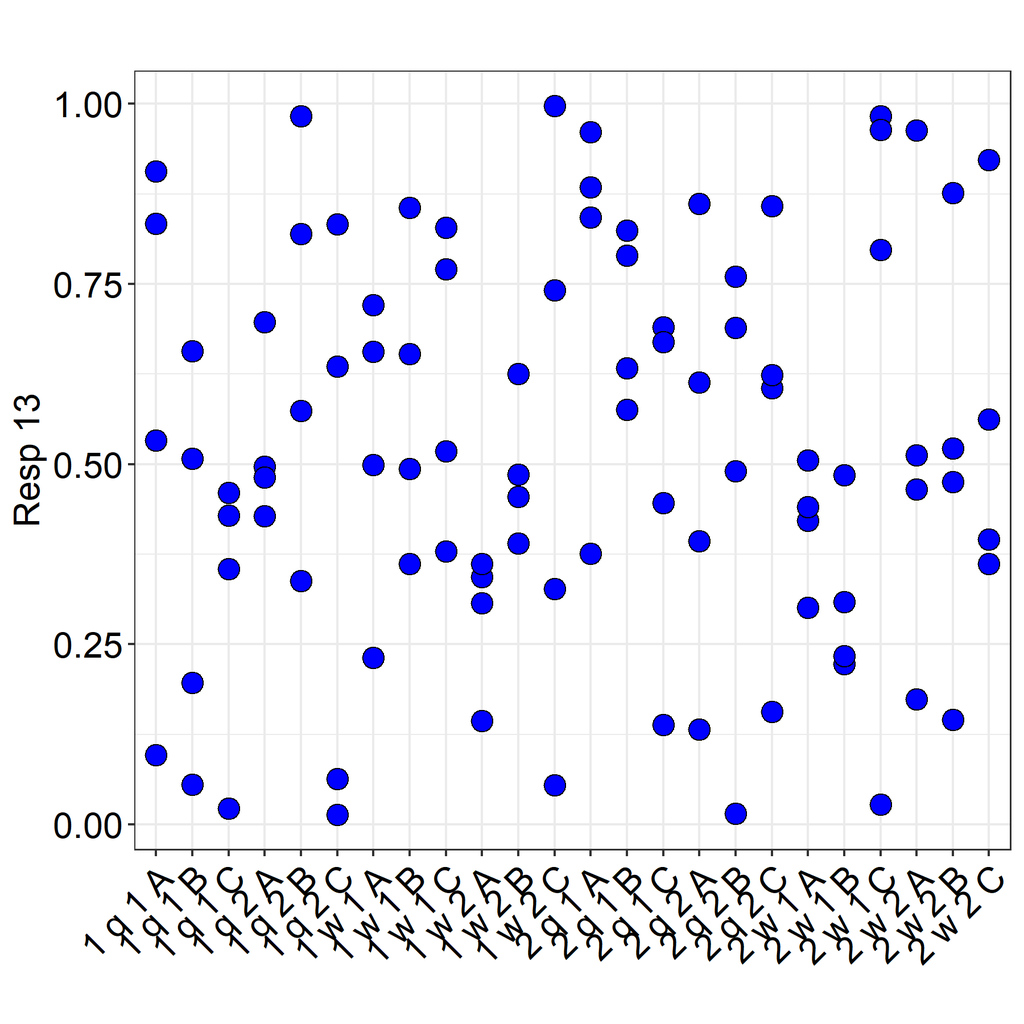

Tip: Use this plot to identify possible outliers.

## Analysis of variance (ANOVA) table

| Effect | Sums of squares | Degrees of freedom | Mean square | F-value | p-value |
| --- | --- | --- | --- | --- | --- |
| Treat 17 | 0.064 | 1 | 0.064 | 0.86 | 0.3556 |
| Treat 18 | 0.014 | 1 | 0.014 | 0.20 | 0.6599 |
| Treat 19 | 0.019 | 1 | 0.019 | 0.26 | 0.6099 |
| Treat 20 | 0.000 | 2 | 0.000 | 0.00 | 0.9981 |
| Treat 17 * Treat 18 | 0.079 | 1 | 0.079 | 1.06 | 0.3068 |
| Treat 17 * Treat 19 | 0.003 | 1 | 0.003 | 0.04 | 0.8458 |
| Treat 17 * Treat 20 | 0.078 | 2 | 0.039 | 0.52 | 0.5940 |
| Treat 18 * Treat 19 | 0.006 | 1 | 0.006 | 0.08 | 0.7849 |
| Treat 18 * Treat 20 | 0.449 | 2 | 0.225 | 3.03 | 0.0546 |
| Treat 19 * Treat 20 | 0.108 | 2 | 0.054 | 0.73 | 0.4852 |
| Treat 17 * Treat 18 * Treat 19 | 0.299 | 1 | 0.299 | 4.03 | 0.0484 |
| Treat 17 * Treat 18 * Treat 20 | 0.041 | 2 | 0.021 | 0.28 | 0.7570 |
| Treat 17 * Treat 19 * Treat 20 | 0.039 | 2 | 0.020 | 0.27 | 0.7671 |
| Treat 18 * Treat 19 * Treat 20 | 0.085 | 2 | 0.042 | 0.57 | 0.5666 |
| Treat 17 * Treat 18 * Treat 19 * Treat 20 | 0.201 | 2 | 0.100 | 1.35 | 0.2653 |
| Residual | 5.342 | 72 | 0.074 |  |  |

Comment: ANOVA table calculated using a Type III model fit, see Armitage et al. (2001).

Conclusion: At the 5% level, there is a statistically significant overall difference between the levels of Treat 17:Treat 18:Treat 19.

Tip: While it is a good idea to consider the overall tests in the ANOVA table, we should not rely on them when deciding whether or not to make pairwise comparisons.

## Model coefficients

|  | Estimate | Std. Error | t-value | p-value |
| --- | --- | --- | --- | --- |
| (Intercept) | 0.5178 | 0.0278 | 18.62 | < 0.0001 |
| Treat 171 | -0.0258 | 0.0278 | -0.93 | 0.3556 |
| Treat 181 | 0.0123 | 0.0278 | 0.44 | 0.6599 |
| Treat 191 | 0.0142 | 0.0278 | 0.51 | 0.6099 |
| Treat 201 | 0.0004 | 0.0393 | 0.01 | 0.9924 |
| Treat 202 | -0.0022 | 0.0393 | -0.06 | 0.9547 |
| Treat 171:Treat 181 | -0.0286 | 0.0278 | -1.03 | 0.3068 |
| Treat 171:Treat 191 | -0.0054 | 0.0278 | -0.20 | 0.8458 |
| Treat 171:Treat 201 | -0.0089 | 0.0393 | -0.23 | 0.8223 |
| Treat 171:Treat 202 | 0.0385 | 0.0393 | 0.98 | 0.3313 |
| Treat 181:Treat 191 | -0.0076 | 0.0278 | -0.27 | 0.7849 |
| Treat 181:Treat 201 | 0.0655 | 0.0393 | 1.67 | 0.1002 |
| Treat 181:Treat 202 | 0.0290 | 0.0393 | 0.74 | 0.4637 |
| Treat 191:Treat 201 | 0.0430 | 0.0393 | 1.09 | 0.2776 |
| Treat 191:Treat 202 | -0.0390 | 0.0393 | -0.99 | 0.3245 |
| Treat 171:Treat 181:Treat 191 | -0.0558 | 0.0278 | -2.01 | 0.0484 |
| Treat 171:Treat 181:Treat 201 | 0.0264 | 0.0393 | 0.67 | 0.5041 |
| Treat 171:Treat 181:Treat 202 | -0.0244 | 0.0393 | -0.62 | 0.5369 |
| Treat 171:Treat 191:Treat 201 | 0.0242 | 0.0393 | 0.62 | 0.5404 |
| Treat 171:Treat 191:Treat 202 | -0.0254 | 0.0393 | -0.65 | 0.5195 |
| Treat 181:Treat 191:Treat 201 | 0.0334 | 0.0393 | 0.85 | 0.3980 |
| Treat 181:Treat 191:Treat 202 | 0.0054 | 0.0393 | 0.14 | 0.8909 |
| Treat 171:Treat 181:Treat 191:Treat 201 | -0.0127 | 0.0393 | -0.32 | 0.7469 |
| Treat 171:Treat 181:Treat 191:Treat 202 | -0.0485 | 0.0393 | -1.23 | 0.2212 |

## Diagnostic plots

### Residuals vs. predicted plot

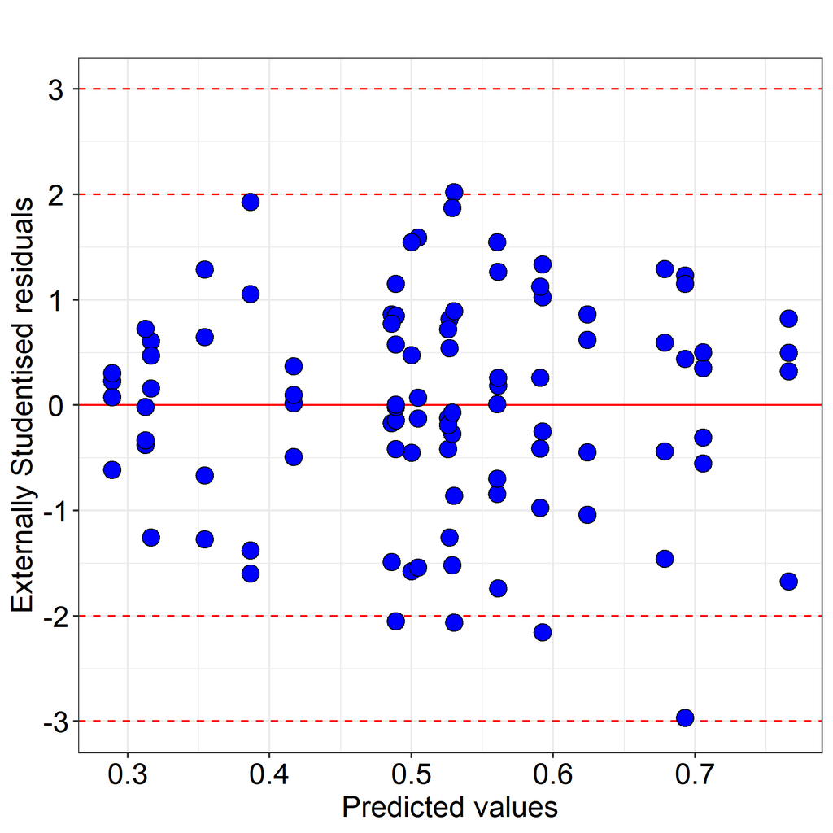

Tip: On this plot look to see if the spread of the points increases as the predicted values increase. If so the response may need transforming.

Tip: Any observation with a residual less than -3 or greater than 3 (SD) should be investigated as a possible outlier.

### Normal probability plot

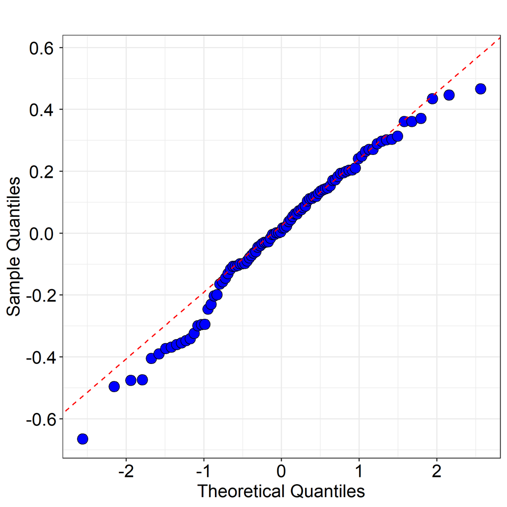

Tip: Check that the points lie along the dotted line. If not then the data may be non-normally distributed.

## Table of the least square (predicted) means with 95% confidence intervals

| Mean ID | Treat 17 | Treat 18 | Treat 19 | Treat 20 | Mean | Lower 95% CI | Upper 95% CI |
| --- | --- | --- | --- | --- | --- | --- | --- |
| 1 | '1' | q | '1' | A | 0.592 | 0.321 | 0.864 |
| 2 | '2' | q | '1' | A | 0.766 | 0.494 | 1.037 |
| 3 | '1' | w | '1' | A | 0.527 | 0.255 | 0.798 |
| 4 | '2' | w | '1' | A | 0.417 | 0.146 | 0.689 |
| 5 | '1' | q | '2' | A | 0.526 | 0.254 | 0.797 |
| 6 | '2' | q | '2' | A | 0.500 | 0.228 | 0.771 |
| 7 | '1' | w | '2' | A | 0.289 | 0.018 | 0.561 |
| 8 | '2' | w | '2' | A | 0.529 | 0.257 | 0.800 |
| 9 | '1' | q | '1' | B | 0.354 | 0.083 | 0.626 |
| 10 | '2' | q | '1' | B | 0.705 | 0.434 | 0.977 |
| 11 | '1' | w | '1' | B | 0.591 | 0.319 | 0.862 |
| 12 | '2' | w | '1' | B | 0.313 | 0.041 | 0.584 |
| 13 | '1' | q | '2' | B | 0.679 | 0.407 | 0.950 |
| 14 | '2' | q | '2' | B | 0.489 | 0.217 | 0.760 |
| 15 | '1' | w | '2' | B | 0.489 | 0.217 | 0.760 |
| 16 | '2' | w | '2' | B | 0.505 | 0.233 | 0.776 |
| 17 | '1' | q | '1' | C | 0.316 | 0.045 | 0.588 |
| 18 | '2' | q | '1' | C | 0.486 | 0.215 | 0.758 |
| 19 | '1' | w | '1' | C | 0.624 | 0.353 | 0.896 |
| 20 | '2' | w | '1' | C | 0.693 | 0.421 | 0.964 |
| 21 | '1' | q | '2' | C | 0.386 | 0.115 | 0.658 |
| 22 | '2' | q | '2' | C | 0.561 | 0.290 | 0.833 |
| 23 | '1' | w | '2' | C | 0.530 | 0.258 | 0.801 |
| 24 | '2' | w | '2' | C | 0.560 | 0.289 | 0.832 |

## Plot of the least square (predicted) means with 95% confidence intervals

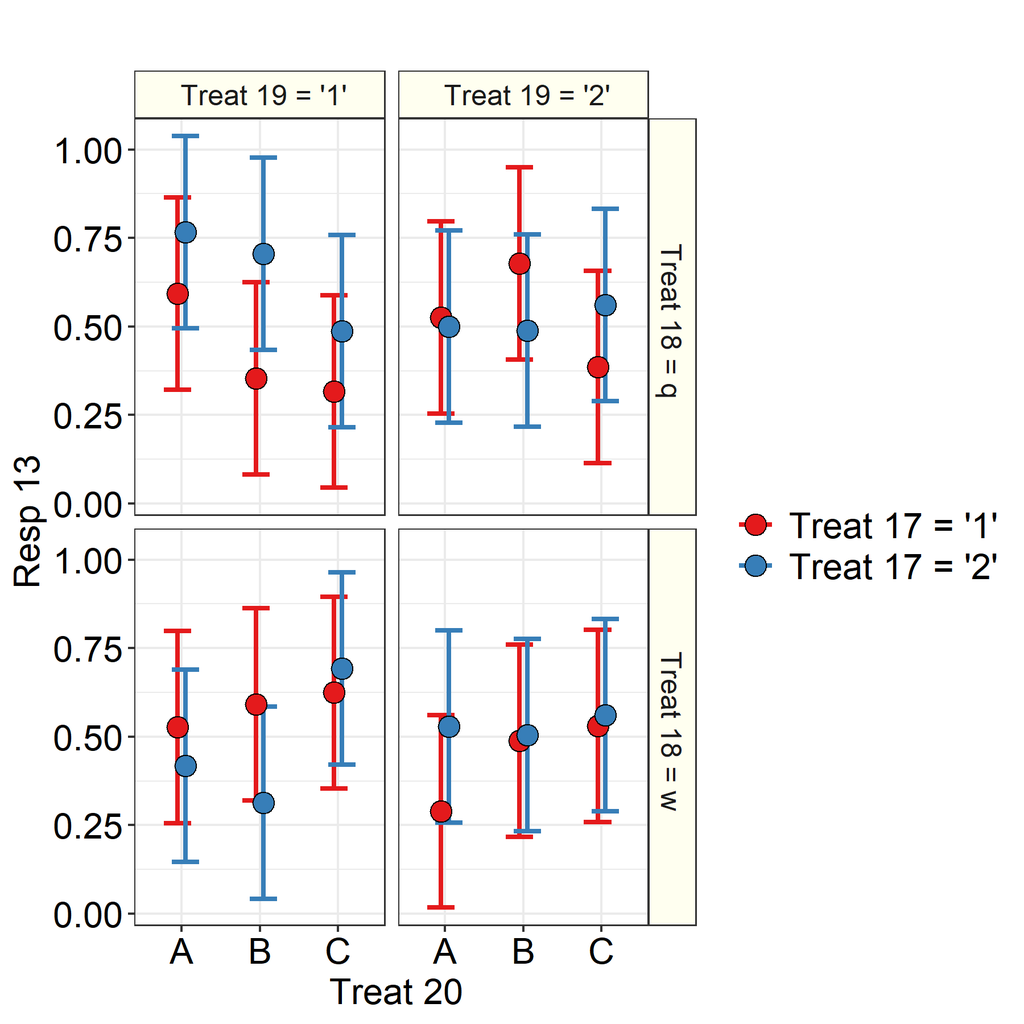

## Analysis description

The data were analysed using a 4-way ANOVA approach, with Treat 17, Treat 18, Treat 19 and Treat 20 as the treatment factors.

For more information on the theoretical approaches that are implemented within this module, see Bate and Clark (2014).

## References

When referring to InVivoStat, please cite 'InVivoStat, version 5.2.0'.

Bate, S.T. and Clark, R.A. (2014). The Design and Statistical Analysis of Animal Experiments. Cambridge University Press.

Armitage, P., Matthews, J.N.S. and Berry, G. (2001). Statistical Methods in Medical Research. 4th edition; John Wiley & Sons. New York.